# Project 1: Finding Great Chocolate Bars!

Yunyi Ru

2024-09-15

# Set Up

```r
library("here")
library("tidyverse")
```

```r
library('tidytuesdayR')
library('ggplot2')
theme_set(theme_bw())
library('ggpubr') # to merge images
library('knitr')
library('reshape2') # to convert wide dataset to long dataset
# load data from tidytuesdayR
# tests if a directory named "data" exists locally
if (!dir.exists(here("data"))) {
    dir.create(here("data"))
}

# saves data only once (not each time you knit a R Markdown)
if (!file.exists(here("data", "chocolate.RDS"))) {
    url_csv <- "https://raw.githubusercontent.com/rfordatascience/tidytuesday/master/data/2022/2022-01-18/chocolate.csv"
    chocolate <- readr::read_csv(url_csv)

# save the file to RDS objects
saveRDS(chocolate, file = here("data", "chocolate.RDS"))
}

# read the .RDS dataset (locally)
chocolate <- readRDS(here('data', 'chocolate.RDS'))
as_tibble(chocolate)
```

```
## # A tibble: 2,530 × 10
##      ref company_manufacturer company_location review_date
##    <dbl> <chr>                <chr>                  <dbl>
##  1  2454 5150                 U.S.A.                  2019
##  2  2458 5150                 U.S.A.                  2019
##  3  2454 5150                 U.S.A.                  2019
##  4  2542 5150                 U.S.A.                  2021
##  5  2546 5150                 U.S.A.                  2021
##  6  2546 5150                 U.S.A.                  2021
##  7  2542 5150                 U.S.A.                  2021
##  8   797 A. Morin             France                  2012
##  9   797 A. Morin             France                  2012
## 10  1011 A. Morin             France                  2013
## # ℹ 2,520 more rows
## # ℹ 6 more variables: country_of_bean_origin <chr>,
## #   specific_bean_origin_or_bar_name <chr>, cocoa_percent <chr>,
## #   ingredients <chr>, most_memorable_characteristics <chr>, rating <dbl>
```

```r
# load gapminder data
library('gapminder')
```

# Part 1: Explore Data

## Question 1

Q: Make a histogram of the rating scores to visualize the overall distribution of scores. Change the number of bins from the default to 10, 15, 20, and 25. Pick on the one that you think looks the best. Explain what the difference is when you change the number of bins and explain why you picked the one you did.

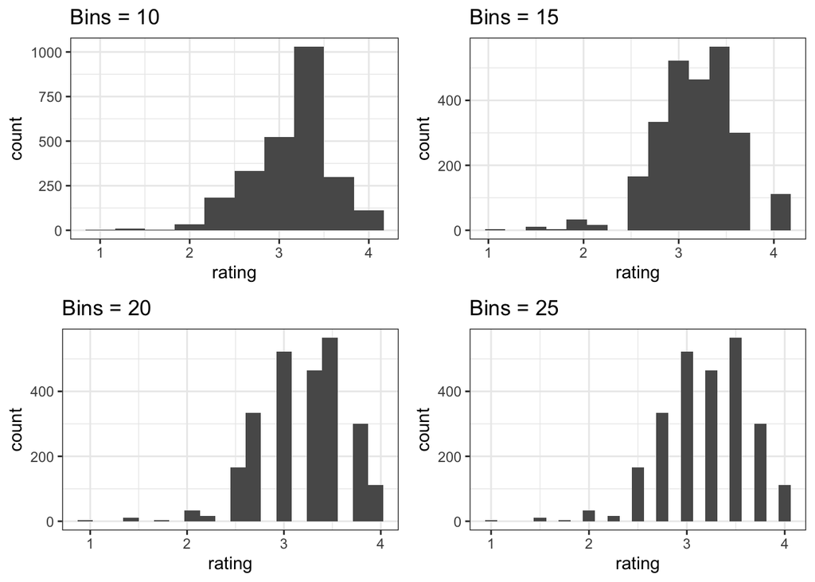

```r
# bin = 10
q1p1 <- ggplot(data = chocolate, aes(x = rating)) +
  geom_histogram(bins = 10) +
  labs(title = 'Bins = 10')

# bin = 15
q1p2 <- ggplot(data = chocolate, aes(x = rating)) +
  geom_histogram(bins = 15) +
  labs(title = 'Bins = 15')

# bin = 20
q1p3 <- ggplot(data = chocolate, aes(x = rating)) +
  geom_histogram(bins = 20) +
  labs(title = 'Bins = 20')

# bin = 25
q1p4 <- ggplot(data = chocolate, aes(x = rating)) +
  geom_histogram(bins = 25) +
  labs(title = 'Bins = 25')

# a big plot
ggarrange(q1p1, q1p2, q1p3, q1p4)
```

A: There’s a difference in data distribution. Generally, we observe that the ratings are concentrated around 3.5. However, in graphs with fewer bins, the two peaks are not clearly visible. In the graphs with 15 and 20 bins, there appears to be a discontinuity in the higher ratings, which may lead to inaccuracies.

I think the bins = 25 one looks the best, because it successfully captures the two peaks around 3 and 3.5.

## Question 2

Q: Consider the countries where the beans originated from. How many reviews come from each country of bean origin?

A: Please see the table below.

```r
q2 <- chocolate %>%
  count(country_of_bean_origin)
kable(q2)
```

| country_of_bean_origin | n |
| --- | --- |
| Australia | 3 |
| Belize | 76 |
| Blend | 156 |
| Bolivia | 80 |
| Brazil | 78 |
| Burma | 1 |
| Cameroon | 3 |
| China | 1 |
| Colombia | 79 |
| Congo | 11 |
| Costa Rica | 43 |
| Cuba | 12 |
| DR Congo | 1 |
| Dominican Republic | 226 |
| Ecuador | 219 |
| El Salvador | 6 |
| Fiji | 16 |
| Gabon | 1 |
| Ghana | 41 |
| Grenada | 19 |
| Guatemala | 62 |
| Haiti | 30 |
| Honduras | 25 |
| India | 35 |
| Indonesia | 20 |
| Ivory Coast | 7 |
| Jamaica | 24 |
| Liberia | 3 |
| Madagascar | 177 |
| Malaysia | 8 |
| Martinique | 1 |
| Mexico | 55 |
| Nicaragua | 100 |
| Nigeria | 3 |
| Panama | 9 |
| Papua New Guinea | 50 |
| Peru | 244 |
| Philippines | 24 |
| Principe | 1 |
| Puerto Rico | 7 |
| Samoa | 3 |
| Sao Tome | 14 |
| Sao Tome & Principe | 2 |
| Sierra Leone | 4 |
| Solomon Islands | 10 |
| Sri Lanka | 2 |
| St. Lucia | 10 |
| St.Vincent-Grenadines | 1 |
| Sulawesi | 1 |
| Sumatra | 1 |
| Suriname | 1 |
| Taiwan | 2 |
| Tanzania | 79 |
| Thailand | 5 |
| Tobago | 2 |
| Togo | 3 |
| Trinidad | 42 |
| U.S.A. | 33 |
| Uganda | 19 |
| Vanuatu | 13 |
| Venezuela | 253 |
| Vietnam | 73 |

## Question 3

Q: What is average rating scores from reviews of chocolate bars that have *Ecuador* as country_of_bean_origin in this dataset? For this same set of reviews, also calculate

1. the total number of reviews and
2. the standard deviation of the rating scores.

Your answer should be a new data frame with these three summary statistics in three columns. Label the name of these columns mean, sd, and total.

A:

```r
# select the country
chocoEcu <- chocolate %>%
  filter(country_of_bean_origin == 'Ecuador')

# calculate the numbers
m_chocoEcu_rating <- format(round(as.numeric(mean(chocoEcu$rating)),2), nsmall=2)
n_chocoEcu_rating <- as.numeric(count(chocoEcu))
sd_chocoEcu_rating <- format(round(as.numeric(sd(chocoEcu$rating)),2), nsmall = 2)

# make the data frame
dfP1Q3 <- data.frame(label = c('mean', 'sd', 'total'),
                     value = c(m_chocoEcu_rating, sd_chocoEcu_rating, n_chocoEcu_rating))

# print result
kable(dfP1Q3)
```

| label | value |
| --- | --- |
| mean | 3.16 |
| sd | 0.51 |
| total | 219 |

## Question 4

Q: Which company location makes the best chocolate (or has the highest ratings on average) with beans from Ecuador?

A: Australia.

```r
chocoEcu_bycomploc_ranking <- chocoEcu %>%
  group_by(company_location) %>%
  summarize(avg_rating = mean(rating, na.rm = TRUE)) %>%
  arrange(desc(avg_rating))

kable(chocoEcu_bycomploc_ranking[1,])
```

| company_location | avg_rating |
| --- | --- |
| Australia | 3.8125 |

## Question 5

Q: Calculate the average rating across all country of origins for beans. Which top 3 countries (for bean origin) have the highest ratings on average?

A: The top 3 countries are Tobago, China, and San Tome & Principe.

```r
rating_by_country <- chocolate %>%
  group_by(country_of_bean_origin) %>%
  summarize(avg_rating = mean(rating, na.rm = TRUE)) %>%
  arrange(desc(avg_rating))

kable(rating_by_country[1:3,])
```

| country_of_bean_origin | avg_rating |
| --- | --- |
| Tobago | 3.625 |
| China | 3.500 |
| Sao Tome & Principe | 3.500 |

## Question 6

Q: Following up on the previous problem, now remove any countries of bean origins that have less than 10 chocolate bar reviews. Now, which top 3 countries have the highest ratings on average?

A: The top 3 countries are Solomon Islands, Congo, and Cuba.

```r
rating_by_country_clean <- chocolate %>%
  group_by(country_of_bean_origin) %>%
  summarize(avg_rating = mean(rating, na.rm = TRUE),
            review_count = n()) %>%
  filter(review_count >= 10) %>%
  arrange(desc(avg_rating))

kable(rating_by_country_clean[1:3,])
```

| country_of_bean_origin | avg_rating | review_count |
| --- | --- | --- |
| Solomon Islands | 3.450000 | 10 |
| Congo | 3.318182 | 11 |
| Cuba | 3.291667 | 12 |

## Question 7

Q: For this last part, let’s explore the relationship between percent chocolate and ratings.

Use the functions in `dplyr`, `tidyr`, and `lubridate` to perform the following steps to the `chocolate` dataset:

1. Identify the countries of bean origin with at least 50 reviews. Remove reviews from countries are not in this list.
2. Using the variable describing the chocolate percentage for each review, create a new column that groups chocolate percentages into one of four groups: (i) <60%, (ii) >=60 to <70%, (iii) >=70 to <90%, and (iii) >=90% (**Hint** check out the `substr()` function in base R and the `case_when()` function from dplyr – see example below).
3. Using the new column described in #2, re-order the factor levels (if needed) to be starting with the smallest percentage group and increasing to the largest percentage group (**Hint** check out the `fct_relevel()` function from `forcats`).
4. For each country, make a set of four side-by-side boxplots plotting the groups on the x-axis and the ratings on the y-axis. These plots should be faceted by country.

On average, which category of chocolate percentage is most highly rated? Do these countries mostly agree or are there disagreements?

A:

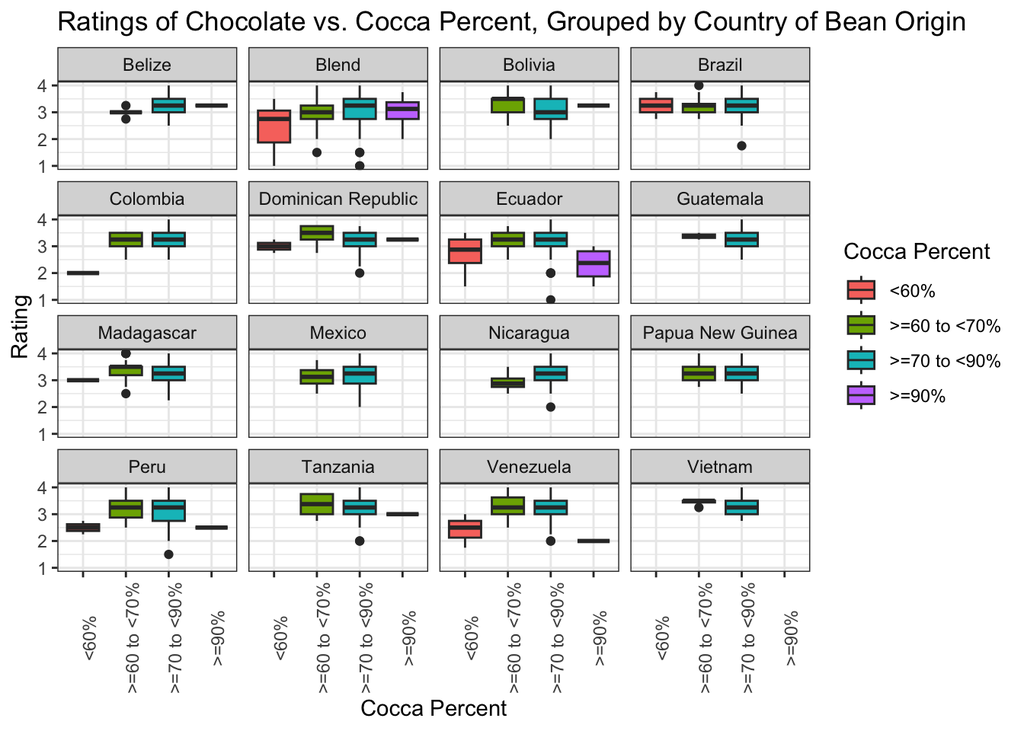

```r
# step 1
chocolate_clean <- chocolate %>%
  group_by(country_of_bean_origin) %>%
  mutate(review_count_by_country = n()) %>%
  filter(review_count_by_country >= 50)

# step 2
chocolate_clean <- chocolate_clean %>%
  mutate(percent_group = case_when(
      cocoa_percent < 60 ~ "<60%",
      cocoa_percent >= 60 & cocoa_percent < 70 ~ ">=60 to <70%",
      cocoa_percent >= 70 & cocoa_percent < 90 ~ ">=70 to <90%",
      cocoa_percent >= 90 ~ ">=90%"
   ))

# step 3
chocolate_clean <- chocolate_clean %>%
  mutate(percent_group = factor(percent_group, levels = c("<60%", ">=60 to <70%", ">=70 to <90%", ">=90%"))) %>%
  arrange(percent_group)

# step 4
ggplot(data = chocolate_clean, aes(x = percent_group, y = rating, fill = percent_group)) +
  geom_boxplot() +
  facet_wrap(~country_of_bean_origin) +
  theme(axis.text.x = element_text(angle = 90)) +
  labs(title = 'Ratings of Chocolate vs. Cocca Percent, Grouped by Country of Bean Origin',
       x = 'Cocca Percent',
       y = 'Rating',
       fill = 'Cocca Percent')
```

```r
# answer the question
# calculate the highest rated cocca percent group for all countries
rating_by_cocca_group <- chocolate_clean %>%
  ungroup() %>%
  group_by(percent_group) %>%
  summarize(avg_rating = mean(rating)) %>%
  arrange(avg_rating)

# calculate the highest rated cocca percent group, grouped by country
rating_by_country <- chocolate_clean %>%
  group_by(country_of_bean_origin, percent_group) %>%
  summarize(avg_rating = mean(rating)) %>%
  arrange(country_of_bean_origin) %>%
  filter(avg_rating == max(avg_rating))
# Do these countries mostly agree or are there disagreements
highest_group_globally <- as.character(pull(rating_by_cocca_group[4,1]))
highest_group_by_country <- as.character(pull(rating_by_country[,2]))

is.equal <- highest_group_by_country == highest_group_globally
summary(is.equal)
```

```
##    Mode   FALSE    TRUE
## logical       8       9
```

Q: On average, the ‘>=60 to <70%’ group is mostly highly rated, while slightly more than half of all countries agree with this outcome.

# Part 2: Join Two Datasets Together

1. Use this dataset it to create a new column called continent in our chocolate dataset1 that contains the continent name for each review where the country of bean origin is.
2. Only keep reviews that have reviews from countries of bean origin with at least 10 reviews.
3. Also, remove the country of bean origin named “Blend”.
4. Make a set of violin plots with ratings on the y-axis and continents on the x-axis.

```r
# step 1 - add continent information
# remove duplication in gapminder, ready for merge
unique_gapminder <- gapminder %>%
  select(country = country, continent) %>%
  distinct()
# have a look at the continent information - Africa Americas Asia Europe Oceania
unique(gapminder$continent)
```

```
## [1] Asia     Europe   Africa   Americas Oceania
## Levels: Africa Americas Asia Europe Oceania
```

```r
# merge
chocolate_part2 <- chocolate %>%
  left_join(unique_gapminder %>% select(country = country, continent),
            by = c("country_of_bean_origin" = "country"))
# Note that there is a problem with the gapminder package - it does not contain countries like Fiji and Vanuatu etc. so they'd appear as NA here

# step 2 - clean data: filter only for >= 10 reviews
chocolate_part2.2 <- chocolate_part2 %>%
  group_by(country_of_bean_origin) %>%
  mutate(review_count_by_country = n()) %>%
  filter(review_count_by_country >= 10)

# deal with NAs
# search for country with missing continent information
missing_countries <- chocolate_part2.2 %>%
  filter(is.na(continent)) %>%
  pull(country_of_bean_origin)
unique(missing_countries)
```

```
##  [1] "Fiji"             "Papua New Guinea" "Sao Tome"         "Vanuatu"
##  [5] "Trinidad"         "Belize"           "Blend"            "Grenada"
##  [9] "Congo"            "Solomon Islands"  "St. Lucia"        "U.S.A."
```

```r
# 'blend' seems to be a typo
# step 3 - drop lines with 'blend'
chocolate_part2.3 <- chocolate_part2.2 %>%
  filter(country_of_bean_origin != 'Blend')

# add continent information for those which are missing
chocolate_part2.3 <- chocolate_part2.3 %>%
  mutate(continent = case_when(
    country_of_bean_origin %in% c("Fiji", "Papua New Guinea", "Vanuatu", "Solomon Islands") ~ "Oceania",
    country_of_bean_origin %in% c("Sao Tome", "Congo") ~ "Africa",
    country_of_bean_origin %in% c("Trinidad", "Belize", "Grenada", "St. Lucia", "U.S.A.") ~ "Americas",
    TRUE ~ continent  # Keep existing continent information if country doesn't match
  ))

# check if any value is missing for now
summary(is.na(chocolate_part2.3$continent))
```

```
##    Mode   FALSE
## logical    2292
```

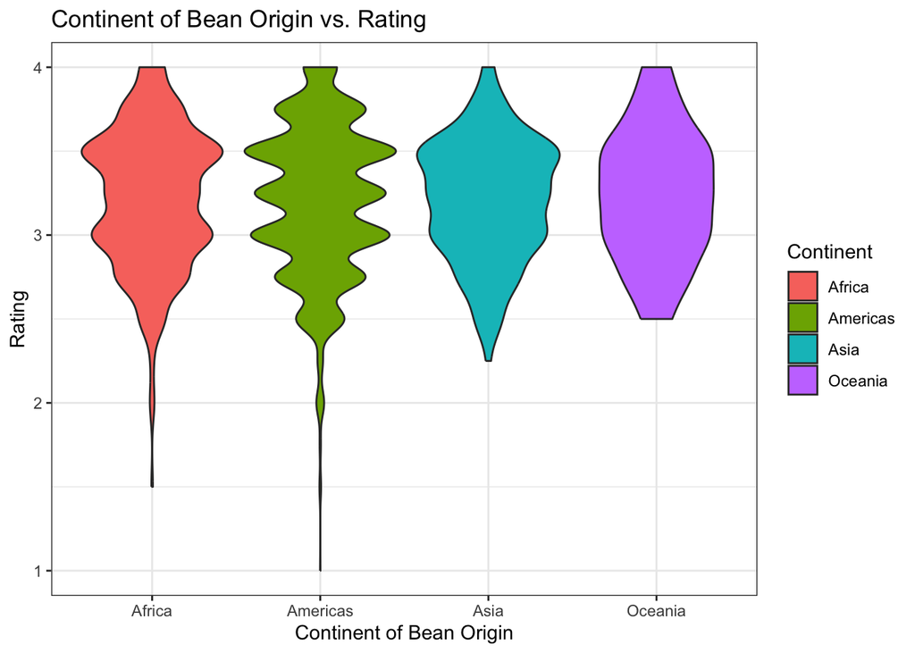

```r
# step 4 - make violin plots
ggplot(data = chocolate_part2.3, aes(x = continent, y = rating, fill = continent)) +
  geom_violin() +
  labs(title = 'Continent of Bean Origin vs. Rating',
       x = 'Continent of Bean Origin',
       y = 'Rating',
       fill = 'Continent')
```

# Part 3: Convert Wide Data into Long Data

1. Create a new set of columns titled beans, sugar, cocoa_butter, vanilla, letchin, and salt that contain a 1 or 0 representing whether or not that review for the chocolate bar contained that ingredient (1) or not (0). See this public gist for how to differentiate S vs S* vs Sa using str_detect() from the stringr package.
2. Create a new set of columns titled char_cocoa, char_sweet, char_nutty, char_creamy, char_roasty, char_earthy that contain a 1 or 0 representing whether or not that the most memorable characteristic for the chocolate bar had that word (1) or not (0). For example, if the word “sweet” appears in the most_memorable_characteristics, then record a 1, otherwise a 0 for that review in the char_sweet column (Hint: check out str_detect() from the stringr package).
3. For each year (i.e. review_date), calculate the mean value in each new column you created across all reviews for that year. (Hint: If all has gone well thus far, you should have a dataset with 16 rows and 13 columns).
4. Convert this wide dataset into a long dataset with a new feature and mean_score column.

```r
chocolate_part3 <- chocolate

# Step 1: create columns (ingredients)
chocolate_part3.1 <- chocolate_part3 %>%
  mutate(
    bean = ifelse(grepl("B", ingredients), 1, 0),
    sugar = ifelse(grepl("S,|S$", ingredients), 1, 0),
    salt = ifelse(grepl("Sa", ingredients), 1, 0),
    cocoa_butter = ifelse(grepl("C", ingredients), 1, 0),
    vanilla = ifelse(grepl("V", ingredients), 1, 0),
    letchin = ifelse(grepl("L", ingredients), 1, 0)
  )

# Step 2: create columns (characteristic)
chocolate_part3.2 <- chocolate_part3.1 %>%
  mutate(
    char_cocoa = ifelse(grepl("cocoa", most_memorable_characteristics), 1, 0),
    char_sweet = ifelse(grepl("sweet", most_memorable_characteristics), 1, 0),
    char_nutty = ifelse(grepl("nutty", most_memorable_characteristics), 1, 0),
    char_creamy = ifelse(grepl("creamy", most_memorable_characteristics), 1, 0),
    char_roasty = ifelse(grepl("roasty", most_memorable_characteristics), 1, 0),
    char_earthy = ifelse(grepl("earthy", most_memorable_characteristics), 1, 0)
  )

# Step 3
chocolate_part3.3 <- chocolate_part3.2 %>%
  group_by(review_date) %>%
  summarize(bean = mean(bean),
            sugar = mean(sugar),
            salt = mean(salt),
            cocoa_butter = mean(cocoa_butter),
            vanilla = mean(vanilla),
            letchin = mean(letchin),
            char_cocoa = mean(char_cocoa),
            char_sweet = mean(char_sweet),
            char_nutty = mean(char_nutty),
            char_creamy = mean(char_creamy),
            char_roasty = mean(char_roasty),
            char_earthy = mean(char_earthy))
kable(chocolate_part3.3)
```

| review_date | bean | sugar | salt | cocoa_butter | vanilla | letchin | char_cocoa | char_sweet | char_nutty | char_creamy | char_roasty | char_earthy |
| --- | --- | --- | --- | --- | --- | --- | --- | --- | --- | --- | --- | --- |
| 2006 | 0.9677419 | 0.9677419 | 0.0000000 | 0.9032258 | 0.6935484 | 0.6935484 | 0.2096774 | 0.1612903 | 0.0322581 | 0.2419355 | 0.0483871 | 0.0645161 |
| 2007 | 0.9452055 | 0.9452055 | 0.0000000 | 0.7671233 | 0.5479452 | 0.3835616 | 0.3424658 | 0.0958904 | 0.0410959 | 0.2328767 | 0.0136986 | 0.0684932 |
| 2008 | 0.9130435 | 0.9021739 | 0.0000000 | 0.7500000 | 0.3586957 | 0.5108696 | 0.1086957 | 0.1304348 | 0.1521739 | 0.0978261 | 0.0434783 | 0.0434783 |
| 2009 | 0.9186992 | 0.9186992 | 0.0000000 | 0.7723577 | 0.3252033 | 0.3414634 | 0.1463415 | 0.1544715 | 0.1544715 | 0.0894309 | 0.0813008 | 0.0731707 |
| 2010 | 0.8545455 | 0.8454545 | 0.0090909 | 0.7090909 | 0.2272727 | 0.3909091 | 0.2181818 | 0.1000000 | 0.1454545 | 0.0909091 | 0.0363636 | 0.0727273 |
| 2011 | 0.9386503 | 0.9141104 | 0.0490798 | 0.6932515 | 0.1595092 | 0.1595092 | 0.1717791 | 0.1104294 | 0.1165644 | 0.1288344 | 0.0736196 | 0.0613497 |
| 2012 | 0.9278351 | 0.8144330 | 0.0721649 | 0.6752577 | 0.1855670 | 0.1237113 | 0.0876289 | 0.1391753 | 0.1030928 | 0.0721649 | 0.0618557 | 0.0463918 |
| 2013 | 0.9672131 | 0.9508197 | 0.0163934 | 0.7759563 | 0.2076503 | 0.2950820 | 0.1748634 | 0.1256831 | 0.1147541 | 0.0710383 | 0.1092896 | 0.0491803 |
| 2014 | 0.9838057 | 0.9433198 | 0.0323887 | 0.6437247 | 0.0688259 | 0.1214575 | 0.0607287 | 0.0971660 | 0.1578947 | 0.0485830 | 0.0971660 | 0.1012146 |
| 2015 | 0.9859155 | 0.9366197 | 0.0000000 | 0.5457746 | 0.0598592 | 0.1197183 | 0.1267606 | 0.1056338 | 0.1091549 | 0.0422535 | 0.1232394 | 0.0809859 |
| 2016 | 0.9815668 | 0.9539171 | 0.0092166 | 0.5944700 | 0.0506912 | 0.1059908 | 0.0921659 | 0.1705069 | 0.1566820 | 0.0552995 | 0.1013825 | 0.1105991 |
| 2017 | 0.9809524 | 0.9714286 | 0.0095238 | 0.5619048 | 0.0285714 | 0.1333333 | 0.1333333 | 0.0952381 | 0.0666667 | 0.0952381 | 0.1238095 | 0.1238095 |
| 2018 | 0.9868421 | 0.9254386 | 0.0000000 | 0.5964912 | 0.0614035 | 0.1315789 | 0.1798246 | 0.1184211 | 0.0789474 | 0.0438596 | 0.1096491 | 0.1228070 |
| 2019 | 1.0000000 | 0.9689119 | 0.0000000 | 0.6787565 | 0.0259067 | 0.2020725 | 0.2590674 | 0.1450777 | 0.0725389 | 0.0880829 | 0.1088083 | 0.0414508 |
| 2020 | 1.0000000 | 1.0000000 | 0.0000000 | 0.5679012 | 0.0370370 | 0.0246914 | 0.2839506 | 0.1604938 | 0.0493827 | 0.0370370 | 0.0987654 | 0.0987654 |
| 2021 | 1.0000000 | 0.9942857 | 0.0000000 | 0.6457143 | 0.0114286 | 0.0800000 | 0.2971429 | 0.1257143 | 0.0971429 | 0.0171429 | 0.0742857 | 0.0685714 |

```r
# Step 4: Wide data to Long Data
chocolate_part3.3_long <- melt(chocolate_part3.3, id.vars = "review_date", variable.name = "feature", value.name = "mean_score")

kable(chocolate_part3.3_long)
```

| review_date | feature | mean_score |
| --- | --- | --- |
| 2006 | bean | 0.9677419 |
| 2007 | bean | 0.9452055 |
| 2008 | bean | 0.9130435 |
| 2009 | bean | 0.9186992 |
| 2010 | bean | 0.8545455 |
| 2011 | bean | 0.9386503 |
| 2012 | bean | 0.9278351 |
| 2013 | bean | 0.9672131 |
| 2014 | bean | 0.9838057 |
| 2015 | bean | 0.9859155 |
| 2016 | bean | 0.9815668 |
| 2017 | bean | 0.9809524 |
| 2018 | bean | 0.9868421 |
| 2019 | bean | 1.0000000 |
| 2020 | bean | 1.0000000 |
| 2021 | bean | 1.0000000 |
| 2006 | sugar | 0.9677419 |
| 2007 | sugar | 0.9452055 |
| 2008 | sugar | 0.9021739 |
| 2009 | sugar | 0.9186992 |
| 2010 | sugar | 0.8454545 |
| 2011 | sugar | 0.9141104 |
| 2012 | sugar | 0.8144330 |
| 2013 | sugar | 0.9508197 |
| 2014 | sugar | 0.9433198 |
| 2015 | sugar | 0.9366197 |
| 2016 | sugar | 0.9539171 |
| 2017 | sugar | 0.9714286 |
| 2018 | sugar | 0.9254386 |
| 2019 | sugar | 0.9689119 |

[output cut: 162 more lines]

# Part 4: Data Visualization

Use the functions in ggplot2 package to make a scatter plot of the mean_scores (y-axis) over time (x-axis). There should be one plot (facet) for each feature. For full credit, your plot should include:

1. An overall title for the plot and a subtitle summarizing key trends that you found. Also include a caption in the figure with your name.
2. Both the observed points for the mean_score, but also a smoothed non-linear pattern of the trend
3. All plots should be shown in the one figure
4. There should be an informative x-axis and y-axis label

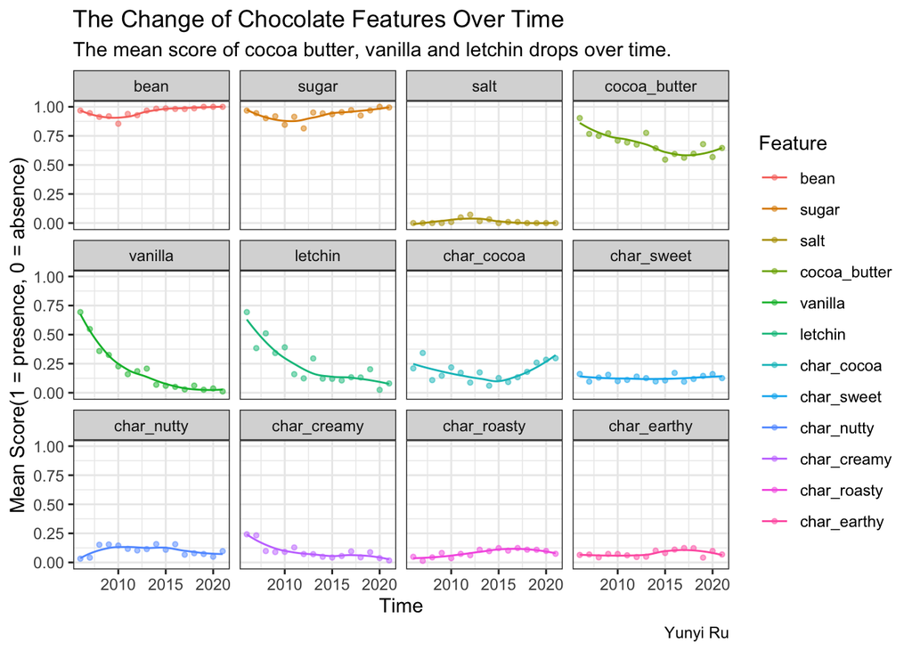

```r
# make plot
ggplot(data = chocolate_part3.3_long, aes(x = review_date, y = mean_score, color = feature)) +
  geom_point(alpha = 0.5, size = 1) +
  geom_smooth(se = FALSE, linewidth = 0.5) + # step 2
  facet_wrap( ~feature) + # step 3
  labs(title = 'The Change of Chocolate Features Over Time', # step1
       subtitle = 'The mean score of cocoa butter, vanilla and letchin drops over time.',
       caption = 'Yunyi Ru',
       x = 'Time', # step 4
       y = 'Mean Score(1 = presence, 0 = absence)', # step 4
       color = 'Feature')
```

# Part 5: Make the Worst Plot You Can!

Q:

1. Make the absolute worst plot that you can. You need to customize it in at least 7 ways to make it awful.
2. In your document, write 1 - 2 sentences about each different customization you added (using bullets – i.e. there should be at least 7 bullet points each with 1-2 sentences), and how it could be useful for you when you want to make an awesome data visualization.

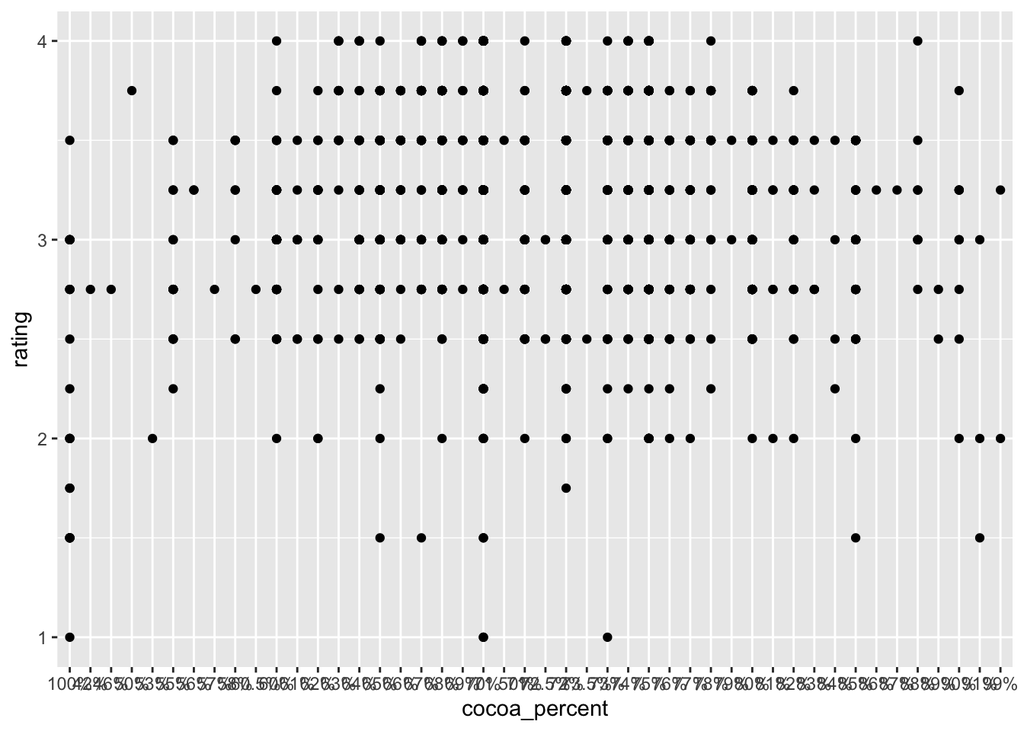

```r
ggplot(data = chocolate, aes(y = rating, x = cocoa_percent)) +
  geom_point() +
  theme_grey()
```

A:

1. Ugly X/y axis labels. Can be changed to a more clear format.
2. Discrete x axis for a continuous valuable. Change data type.
3. Unordered x axis (with 100% at the bottom). Change data type to continuous should fix this problem.
4. The grey theme just looks awful. I’d prefer theme_bw().
5. Missing title, subtitle, etc. Just add those elements.
6. A little bit ugly-looking and biased scatterplot. Many points are merged together. Maybe a violin plot, boxplot, or geom_jitter() would help.
7. No color scheme, makes it hard to read. Change color scheme will make it look much better.

# Part 6: Make My Plot A Better Plot!

The goal is to take my sad looking plot and make it better!

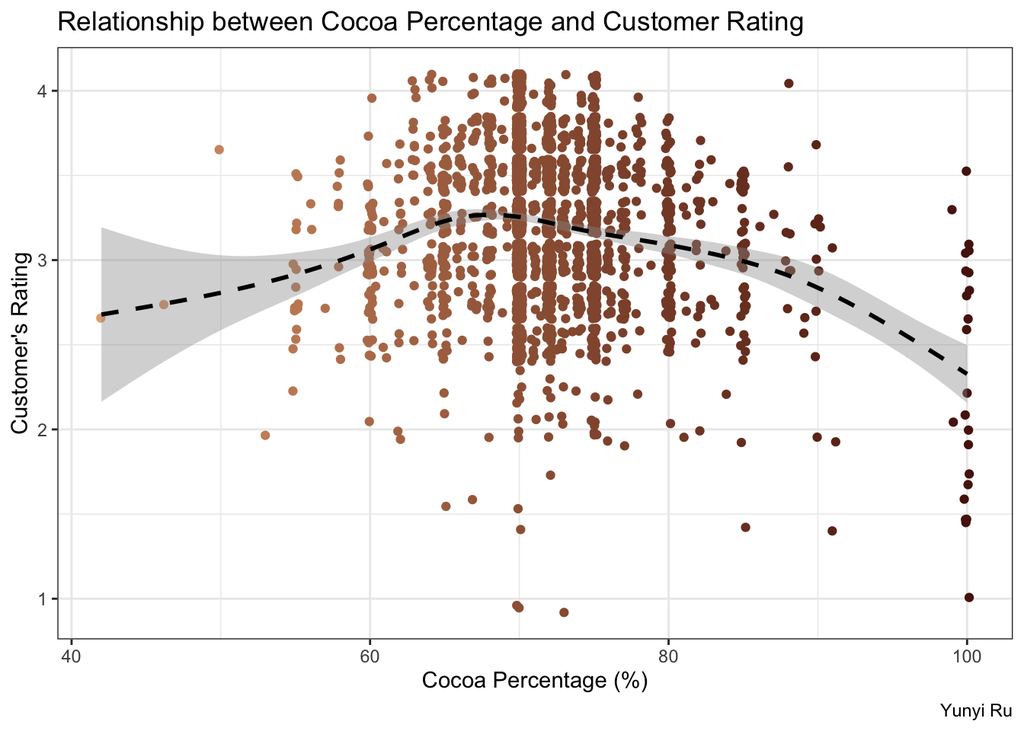

```r
# fix the x axis
chocolate_part6 <- chocolate %>%
  filter(!is.na(cocoa_percent)) %>% # drop NA
  mutate(cocoa_percent = as.numeric(gsub("%", "", cocoa_percent))) # convert to numeric

# plot
ggplot(data = chocolate_part6, aes(y = rating, x = cocoa_percent)) +
  geom_jitter(aes(color = cocoa_percent)) + # use jitter to make it look better
  scale_color_continuous(low = '#e6ac80', high = '#561a0e') +
  geom_smooth(color = 'black', linetype = 2) + # show the trend
  labs(title = "Relationship between Cocoa Percentage and Customer Rating",
       caption = 'Yunyi Ru',
       x = 'Cocoa Percentage (%)',
       y = "Customer's Rating") + # add labels
  theme(legend.position="none")
```